# spell_checking

## Spell checking project

### Finding all mis-spells from corpus

The following steps were first performed to find all the mis-spells

1. TEXT elements were extracted from the raw corpus SGML files and written into one file called "corpus.html"
2. This file was ran through the unix spell utility thus producing the list of all mis-spells in file "all_misspells.txt"
3. The mis-spells were read into a pandas dataframe. Duplicates were dropped as well as words starting with capital letter.
4. A program was created to construct a dictionary and remaining mis-spells were dropped if the word was found from the british dictionary.

Multiple functions were written this task:

- create_aff_dict: creates a python dictionary that has all the affix rules
- get_affixes: returns all the affixed forms of a given word (e.g. abandon/DGRS produces 5 words in total)
- apply_rule: applies the rule defined by certain affix (e.g. E > -E,ING # As in file > filing)
- build_dictionary: builds the full dictionary with affixed words to one data frame (british or american). British was saved to csv-file for later use.
- find_candidates: takes in the mis-spelled word and dictionary and outputs all the correction candidates based on Damerau-Levenshtein distance

```python
# Extracting corpus for unix spell
from collections import Counter
import re
import os
from lxml import html
from bs4 import BeautifulSoup

corpus = os.listdir('C:/data-science-studies/intro-to-nlp/Spell checking exercise/Corpus-spell-AP88')

file_path = 'C:/data-science-studies/intro-to-nlp/Spell checking exercise/Corpus-spell-AP88/'
text = []

for c in corpus:
    t = ''
    with open(file_path + c) as file:
        contents = file.read()
        soup = BeautifulSoup(contents, 'html.parser')
        meta_attrs = soup.findAll('text')

    for meta_attr in meta_attrs:
        t += ' ' + meta_attr.text

    text.append(t)

text_file = open("corpus.html", "w")
text_file.writelines(text)
text_file.close()
```

```python
# Functions for creating dictionary as data frame
import pandas as pd
import regex as re
from jellyfish import damerau_levenshtein_distance as dld

def create_aff_dict(path):
    aff_file = open(path, 'r')
    Lines = aff_file.readlines()

    aff = {}
    for i, line in enumerate(Lines):
        if line[:4] == 'flag':
            letter = re.findall('([A-Z])', line)[0]
            rule = {}
            j = 1
            while i+j<593 and Lines[i+j].strip() != '':
                rule[Lines[i+j].strip().split()[0]] = Lines[i+j].strip().split()[2]
                j += 1
            aff[letter] = rule
    return aff

def get_affixes(word, aff):
    word = word.strip().split("/")
    last_letters = word[0][-2:].upper()
    affixed = [word[0]]
    if len(word) > 1:
        for c in word[1]:
            for x in aff[c].keys():
                rule = aff[c][x]
                if x[-1:] == last_letters[1] and x[:1] != '[':
                    affixed.append(apply_rule(word[0], rule, c))
                elif x[-1:] == last_letters[1] and x[:2] == '[^' and last_letters[0] not in x[2:-2]:
                    affixed.append(apply_rule(word[0], rule, c))
                elif x[-1:] == last_letters[1] and x[:2] != '[^' and last_letters[0] in x[1:-2]:
                    affixed.append(apply_rule(word[0], rule, c))
                elif x[-1:] == ']' and x[:2] == '[^' and last_letters[1] not in x[2:-1]:
                    affixed.append(apply_rule(word[0], rule, c))
                elif x[-1:] == ']' and x[:2] != '[^' and last_letters[1] in x[1:-1]:
                    affixed.append(apply_rule(word[0], rule, c))
                elif x[0]=='.':
                    affixed.append(apply_rule(word[0], rule, c))
    return affixed

def apply_rule(word, rule, letter):
    if letter in 'AIU':
        final_word = rule.lower() + word
    else:
        try:
            final_word = word[:-1] + rule.split(',')[1].lower() # eg. remove Y and add IES
        except:
            final_word = word + rule.lower() # eg. add ES
    return final_word

def build_dictionary(lang, affixes):
    dict = pd.Series()
    # first build english
    for i in range(4):
        dict_file = open('Dictionary/english/english.'+str(i), 'r')
        Lines = dict_file.readlines()
        for line in Lines:
            words = get_affixes(line, affixes)
            s = pd.Series(words)
            dict = pd.concat([dict, s])
    # then add either british or american
    for i in range(3):
        dict_file = open('Dictionary/english/'+lang+'.'+str(i), 'r')
        Lines = dict_file.readlines()
        for line in Lines:
            words = get_affixes(line, affixes)
            s = pd.Series(words)
            dict = pd.concat([dict, s])
    return dict.reset_index(drop=True)

def find_candidates(word, dictionary):
    def dld_test(x):
        return dld(word, str(x))<=1
    boolean = dictionary["word"].apply(dld_test)
    cands = dictionary[boolean].drop_duplicates(ignore_index=True).values.flatten()
    return (cands, len(cands))
```

```python
# Processing of mis-spells
import pandas as pd
import numpy as np
from tqdm.notebook import tqdm
#from ipywidgets import IProgress

misspells = pd.read_csv('all_misspells.txt', names=['word']).dropna()

# Dropping duplicate mis-spells
misspells = misspells.drop_duplicates(ignore_index=True)

# Dropping mis-spells that start with capital letter
bool = pd.Series(misspells.word).str[0].str.islower()
misspells = misspells[bool].reset_index(drop=True)

# Building british dictionary (takes around 5min, can also be read from csv-file)
aff = create_aff_dict('Dictionary\english\english.aff')
# d = build_dictionary('british', aff)
d = pd.read_csv('british_dictionary.csv', names=['word'], header=1).astype('string')
# Dropping mis-spells that are found from dictionary
check_dict = misspells.word.isin(d.word)
misspells = misspells[~check_dict].reset_index(drop=True).astype('string')

# Calculating candidate correction counts and storing results into csv for later use
#misspells = misspells.head(100)
pbar = tqdm.pandas(desc="finding candidate counts")
misspells["corr_count"] = misspells.progress_apply(lambda x: find_candidates(x.word, d)[1], axis=1)
misspells.to_csv('preprocessed_misspells.csv', index=False)
```

### Finding possible corrections from dictionary and performing spell-checking algorithm

In the following section we find the possible corrections from the dictionary and also the respective transformation (deletion, insertion, substitution, reversal). Based on that information we perform the spell checking algorithm based on the paper by Kernighan et al.

Multiple functions were written for the algorithm:

- get_transformation: gets the correct transformation and characters for the given mis-spell and correction candidate
- construct_df: constructs the base data frame that has the mis-spell, correction candidate, transformation and xy characters
- find_word_count: finds the corpus word count for a given word
- char_count: finds the corpus character count for a given combination of characters. (output depends on the transformation type)
- confusion_matrix_value: gets the confusion matrix value for given transformation type and xy characters
- add_columns: add some intermediate columns to the base data frame
- calc_probabilites: calculates intermediate probabilites and the final normalized score (%)
- random_misspells: selects n count of random mis-spells that have more than 1 candidate corrections

```python
from Levenshtein import editops

def get_transformation(word, candidate):
    transf = editops(word, candidate)
    if len(transf) > 1:
        type = "reversal"
        start = transf[0][1]
        xy = candidate[start:start+2]
    elif transf[0][0] == 'delete':
        type = "insertion"
        start = transf[0][1] - 1
        if start < 0:
            xy = "@" + word[0]
        else:
            xy = word[start:start+2]
    elif transf[0][0] == 'insert':
        type = "deletion"
        start = transf[0][1] - 1
        if start < 0:
            xy = "@" + candidate[0]
        else:
            xy = candidate[start:start+2]
    else:
        type = "substitution"
        start = transf[0][1]
        xy = word[start] + candidate[start]
    return (type, xy.lower())

def construct_df(misspells, dictionary):
    df = pd.DataFrame(data={'word': misspells})
    df['correction'] = df.apply(lambda x: find_candidates(x['word'], dictionary)[0], axis=1)
    df = df.explode('correction').dropna()
    df['transformation'] = df.apply(lambda x: get_transformation(x['word'], x['correction'])[0], axis=1)
    df['xy'] = df.apply(lambda x: get_transformation(x['word'], x['correction'])[1], axis=1)
    return df
```

In following section the "TEXT" blocks were extracted from the SGML with BeautifulSoup package and appended into one list. This list was fed into sklearn CountVectorizer to tokenize and get the word counts in all the corpus.

```python
import os
from bs4 import BeautifulSoup
from sklearn.feature_extraction.text import CountVectorizer
import numpy as np

corpus = os.listdir('C:/data-science-studies/intro-to-nlp/Spell checking exercise/Corpus-spell-AP88')
file_path = 'C:/data-science-studies/intro-to-nlp/Spell checking exercise/Corpus-spell-AP88/'
text = []
word_counts = pd.DataFrame()

for c in corpus:
    t = ''
    with open(file_path + c) as file:
        contents = file.read()
        soup = BeautifulSoup(contents, 'html.parser')
        meta_attrs = soup.findAll('text')

    for meta_attr in meta_attrs:
        t += ' ' + meta_attr.text

    text.append(t)

cv = CountVectorizer(stop_words='english')
cv_matrix = cv.fit_transform(text)
columns=cv.get_feature_names_out()
word_counts = pd.DataFrame(cv_matrix.toarray(), columns=columns)
word_counts = word_counts.sum(axis=0).T
word_counts.to_csv('corpus_word_counts.csv', index=True)
```

```python
import random
from tqdm.notebook import tqdm
import numpy as np
import matplotlib.pyplot as plt
from scipy.optimize import curve_fit

# Reading word counts from csv file
word_counts = pd.read_csv('corpus_word_counts.csv', names=['count'])

def find_word_count(x, wc):
    try:
        return wc.loc[x, 'count']
    except:
        return 0


def char_count(xy, transf):
    if transf in ['deletion', 'reversal']:
        return sum(element.count(xy) for element in text)
    elif transf == 'insertion':
        return sum(element.count(xy[0]) for element in text)
    else:
        return sum(element.count(xy[1]) for element in text)

def confusion_matrix_value(xy, transf):
    if transf in ['deletion', 'insertion']:
        matrix = pd.read_csv(transf + '_matrix.txt', header=0, sep=' ')
        index = matrix.columns
        matrix.index = index.append(pd.Index(['@']))
        try:
            return matrix.loc[xy[0], xy[1]]
        except:
            return 0
    else:
        matrix = pd.read_csv(transf + '_matrix.txt', header=0, sep=' ')
        matrix.index = matrix.columns
        try:
            return matrix.loc[xy[0], xy[1]]
        except:
            return 0

def add_columns(candidates, wc):
    candidates['frequency'] = candidates.apply(lambda x: find_word_count(x['correction'], wc), axis=1)
    candidates['confusion_mat'] = candidates.apply(lambda x: confusion_matrix_value(x['xy'], x['transformation']), axis=1)
    candidates['token_count'] = wc["count"].sum()
    candidates['vocabulary'] = pd.read_csv('british_dictionary.csv', names=['word'], header=0).shape[0]
    pbar = tqdm.pandas(desc="finding xy char counts")
    candidates['xy_count'] = candidates.progress_apply(lambda x: char_count(x['xy'].replace("@", " "), x['transformation']), axis=1)
    return candidates

def calc_probabilities(candidates, wc, d):
    wc_grouped = wc.groupby(by=['count'])['count'].count()
    xdata = wc_grouped.index.to_numpy()
    ydata = wc_grouped.to_numpy()
    popt, pcov = curve_fit(gt_fit, xdata[30:], ydata[30:])
    check_dict = wc.index.isin(d.word)
    words_in_corpus = wc[check_dict].shape[0]
    candidates['p_c'] = (candidates['frequency'] + 0.5)/(candidates['token_count']+0.5*candidates['vocabulary'])
    candidates['p_c_gt'] = candidates.apply(lambda x: apply_good_turing(x['frequency'], popt, wc_grouped, x['vocabulary'], words_in_corpus), axis=1)
    candidates['p_tc'] = pd.to_numeric(candidates['confusion_mat'])/candidates['xy_count']
    candidates['p'] = candidates['p_c']*candidates['p_tc']
    candidates['p_gt'] = candidates['p_c_gt']*candidates['p_tc']
    candidates['%'] = (100*candidates['p']/candidates.groupby(level=0).p.transform(np.sum)).round(1)
    candidates['%_gt'] = (100*candidates['p_gt']/candidates.groupby(level=0).p_gt.transform(np.sum)).round(1)
    return candidates

def random_misspells(misspells, count):
    found = 0
    while found < count:
        df2 = misspells.sample(count-found)
        df2["count"] = df2.apply(lambda x: find_candidates(x.word, d)[1], axis=1)
        df2 = df2[df2["count"] > 1]
        found = df2.shape[0]
    return df2["word"].tolist()

def gt_fit(x, a, b, c):
        return a/x + b*x + c

def apply_good_turing(freq, popt, wc_g, vocab, wc_tot):
    try:
        if freq == 0:
            return (freq+1)*wc_g.loc[freq+1]/(wc_g.sum()*(vocab-wc_tot))
        else:
            return (freq+1)*wc_g.loc[freq+1]/(wc_g.sum()*wc_g.loc[freq])
    except:
        return (freq+1)*gt_fit(freq, *popt)/(wc_g.sum()*gt_fit(freq, *popt))
```

In the following section we use the above defined functions to perform the algorithm by Kernighan et al. and find the most likely correction for an arbitrarily selected mis-spell.

The resulting data frame has the following columns

- mis-spelled word
- correction candidate
- transformation for the correction
- characters in the transformation
- frequency of the correction in the corpus
- corresponding confusion matrix value
- total token count in the corpus
- total word count in british vocabulary
- xy count: count of characters in the corpus
- p_c: prior or frequency of the correction candidate
- p_tc: conditional probability of typo given the correction candidate
- p: raw score
- %: normalized score as percentage
- %_gt: normalized score with Good-Turing smoothing

```python
n = 5 # Number of random mis-spells to analyze, try with 2 for starter
misspells = pd.read_csv('preprocessed_misspells.csv', header=0) # Reading mis-spells with candidate counts
d = pd.read_csv('british_dictionary.csv', names=['word'], header=1).astype('string') # Reading dictionary
wc = pd.read_csv('corpus_word_counts.csv', names=["count"]) # Reading corpus word counts
wc = wc[wc.index.notnull()] # Remove one NaN from index
f_misspells = misspells[misspells["corr_count"]>1]
selected_misspells = f_misspells["word"].sample(n).tolist()
# selected_misspells = ['mroe']
print("Random mis-spells selected and processing started.")
df = construct_df(selected_misspells, d)
print("Candidate corrections and respective transformations found.")
df = add_columns(df, wc)
df = calc_probabilities(df, wc, d)
pd.set_option('display.max_rows', None)
display(df)
```

```
Random mis-spells selected and processing started.
Candidate corrections and respective transformations found.
```

|  | word | correction | transformation | xy | frequency | confusion_mat | token_count | vocabulary | xy_count | p_c | p_c_gt | p_tc | p | p_gt | % | %_gt |
| --- | --- | --- | --- | --- | --- | --- | --- | --- | --- | --- | --- | --- | --- | --- | --- | --- |
| 0 | demonstraters | demonstrates | insertion | er | 195 | 83 | 18024252 | 139498 | 18771878 | 1.080469e-05 | 0.001189 | 4.421508e-06 | 4.777300e-11 | 5.255687e-09 | 4.7 | 1.2 |
| 0 | demonstraters | demonstrators | substitution | eo | 2118 | 93 | 18024252 | 139498 | 11234403 | 1.170830e-04 | 0.051404 | 8.278143e-06 | 9.692299e-10 | 4.255268e-07 | 95.3 | 98.8 |
| 1 | paan | pagan | deletion | ag | 30 | 18 | 18024252 | 139498 | 301907 | 1.685642e-06 | 0.000173 | 5.962101e-05 | 1.004997e-10 | 1.029231e-08 | 12.9 | 23.3 |
| 1 | paan | pain | substitution | ai | 942 | 118 | 18024252 | 139498 | 11213012 | 5.208909e-05 | 0.001906 | 1.052349e-05 | 5.481589e-10 | 2.006103e-08 | 70.5 | 45.4 |
| 1 | paan | pan | insertion | aa | 1316 | 15 | 18024252 | 139498 | 12995622 | 7.275892e-05 | 0.007987 | 1.154235e-06 | 8.398088e-11 | 9.218983e-09 | 10.8 | 20.9 |
| 1 | paan | pawn | substitution | aw | 59 | 1 | 18024252 | 139498 | 2406969 | 3.288383e-06 | 0.000330 | 4.154603e-07 | 1.366192e-12 | 1.370036e-10 | 0.2 | 0.3 |
| 1 | paan | plan | substitution | al | 11335 | 0 | 18024252 | 139498 | 6019177 | 6.264784e-04 | 0.068748 | 0.000000e+00 | 0.000000e+00 | 0.000000e+00 | 0.0 | 0.0 |
| 1 | paan | paean | deletion | ae | 9 | 3 | 18024252 | 139498 | 36778 | 5.250359e-07 | 0.000054 | 8.157050e-05 | 4.282744e-11 | 4.403360e-09 | 5.5 | 10.0 |
| 1 | paan | pean | substitution | ae | 0 | 342 | 18024252 | 139498 | 18771878 | 2.763347e-08 | 0.000004 | 1.821874e-05 | 5.034470e-13 | 6.904680e-11 | 0.1 | 0.2 |
| 2 | suporting | sporting | insertion | su | 239 | 7 | 18024252 | 139498 | 10052377 | 1.323643e-05 | 0.000922 | 6.963527e-07 | 9.217225e-12 | 6.419126e-10 | 0.0 | 0.0 |
| 2 | suporting | supporting | deletion | pp | 1458 | 93 | 18024252 | 139498 | 171439 | 8.060683e-05 | 0.008848 | 5.424670e-04 | 4.372654e-08 | 4.799894e-06 | 100.0 | 100.0 |
| 3 | reviewd | review | insertion | wd | 3577 | 1 | 18024252 | 139498 | 2406969 | 1.977175e-04 | 0.021699 | 4.154603e-07 | 8.214375e-11 | 9.015149e-09 | 7.0 | 8.0 |
| 3 | reviewd | reviewed | deletion | we | 679 | 11 | 18024252 | 139498 | 404867 | 3.755388e-05 | 0.003608 | 2.716942e-05 | 1.020317e-09 | 9.803933e-08 | 86.5 | 86.6 |
| 3 | reviewd | reviews | substitution | ds | 466 | 30 | 18024252 | 139498 | 10052377 | 2.578203e-05 | 0.002060 | 2.984369e-06 | 7.694307e-11 | 6.147092e-09 | 6.5 | 5.4 |
| 4 | oO | of | substitution | of | 0 | 0 | 18024252 | 139498 | 3128188 | 2.763347e-08 | 0.000004 | 0.000000e+00 | 0.000000e+00 | 0.000000e+00 | 0.0 | 0.0 |
| 4 | oO | oh | substitution | oh | 563 | 0 | 18024252 | 139498 | 6804680 | 3.114292e-05 | 0.002394 | 0.000000e+00 | 0.000000e+00 | 0.000000e+00 | 0.0 | 0.0 |
| 4 | oO | on | substitution | on | 0 | 0 | 18024252 | 139498 | 11065510 | 2.763347e-08 | 0.000004 | 0.000000e+00 | 0.000000e+00 | 0.000000e+00 | 0.0 | 0.0 |
| 4 | oO | or | substitution | or | 0 | 2 | 18024252 | 139498 | 9839649 | 2.763347e-08 | 0.000004 | 2.032593e-07 | 5.616759e-15 | 7.703278e-13 | 0.0 | 0.1 |
| 4 | oO | ox | substitution | ox | 31 | 0 | 18024252 | 139498 | 276255 | 1.740908e-06 | 0.000198 | 0.000000e+00 | 0.000000e+00 | 0.000000e+00 | 0.0 | 0.0 |
| 4 | oO | MO | substitution | om | 0 | 0 | 18024252 | 139498 | 3461997 | 2.763347e-08 | 0.000004 | 0.000000e+00 | 0.000000e+00 | 0.000000e+00 | 0.0 | 0.0 |
| 4 | oO | om | substitution | om | 14 | 0 | 18024252 | 139498 | 3461997 | 8.013706e-07 | 0.000086 | 0.000000e+00 | 0.000000e+00 | 0.000000e+00 | 0.0 | 0.0 |
| 4 | oO | op | substitution | op | 50 | 14 | 18024252 | 139498 | 3078539 | 2.790980e-06 | 0.000295 | 4.547612e-06 | 1.269229e-11 | 1.341546e-09 | 99.9 | 99.9 |
| 4 | oO | ow | substitution | ow | 2 | 0 | 18024252 | 139498 | 2406969 | 1.381673e-07 | 0.000010 | 0.000000e+00 | 0.000000e+00 | 0.000000e+00 | 0.0 | 0.0 |
| 4 | oO | oz | substitution | oz | 99 | 0 | 18024252 | 139498 | 168874 | 5.499060e-06 | 0.000581 | 0.000000e+00 | 0.000000e+00 | 0.000000e+00 | 0.0 | 0.0 |
| 4 | oO | CO | substitution | oc | 0 | 1 | 18024252 | 139498 | 4623655 | 2.763347e-08 | 0.000004 | 2.162791e-07 | 5.976542e-15 | 8.196713e-13 | 0.0 | 0.1 |

### Extra: Good-Turing smoothing

For Good-Turing smoothing a data frame that contains frequency of frequencies was calculated from the corpus word counts. Also, the best function to be fitted for this data was determined. We ended up in f(x) = a/x + b*x + c where a, b and c are constants. See fit in the plot below.

[output not shown]

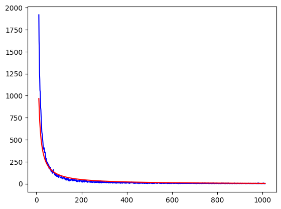

```python
import numpy as np
import matplotlib.pyplot as plt
from scipy.optimize import curve_fit

def func(x, a, b, c):
    #return a * np.exp(-b * x) + c
    return a/x + b*x + c
    #return a + b*np.log(x)

word_counts = pd.read_csv('corpus_word_counts.csv', names=['count'])
word_counts = word_counts[word_counts.index.notnull()]
grouped = word_counts.groupby(by=['count'])['count'].count()

xdata = grouped.index.to_numpy()
ydata = grouped.to_numpy()
popt, pcov = curve_fit(func, xdata[30:], ydata[30:])

plt.plot(xdata[10:1000], ydata[10:1000], 'b-', label='data')
plt.plot(xdata[10:1000], func(xdata[10:1000], *popt), 'r-')
```